# TIGPS2023主要照顧者問卷成果報告

### 上一代_自己父親和照顧者感情好不好 (樣本數=3302)

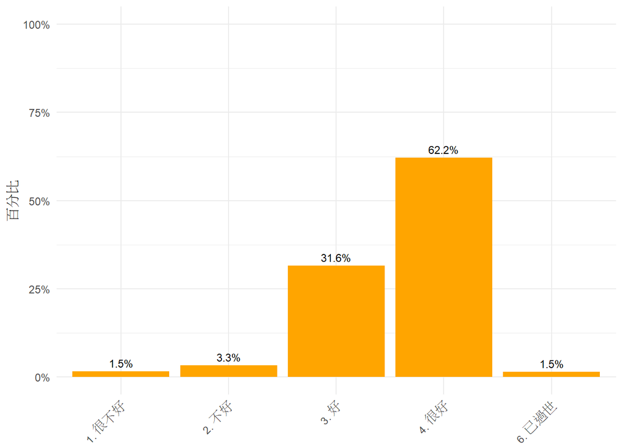

### 上一代_自己母親年齡 (樣本數=3049)

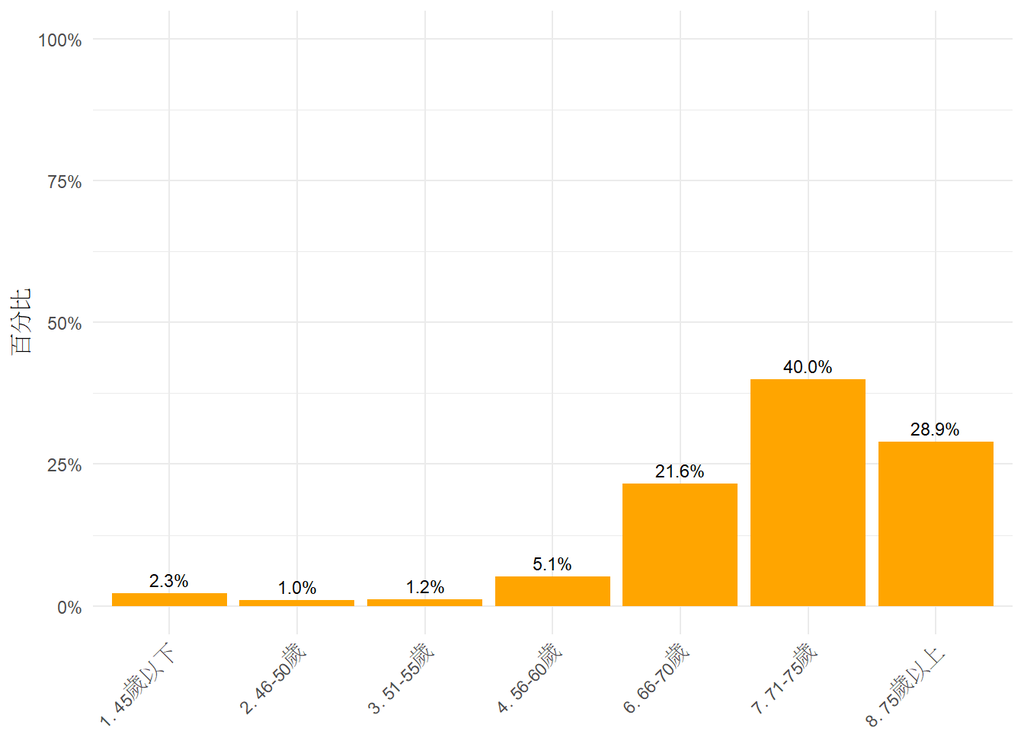

### 上一代_自己母親教育程度 (樣本數=3681)

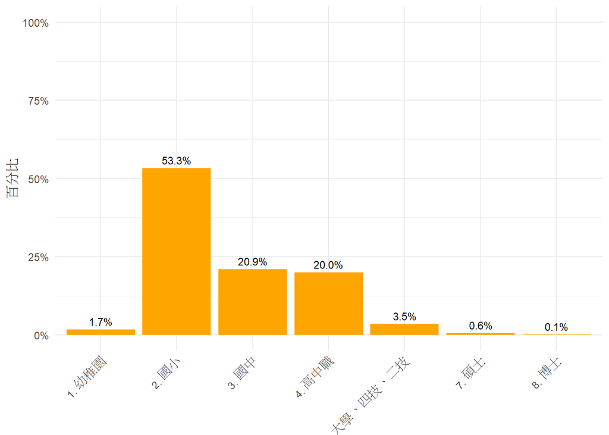

### 上一代_自己母親健康狀況 (樣本數=4195)

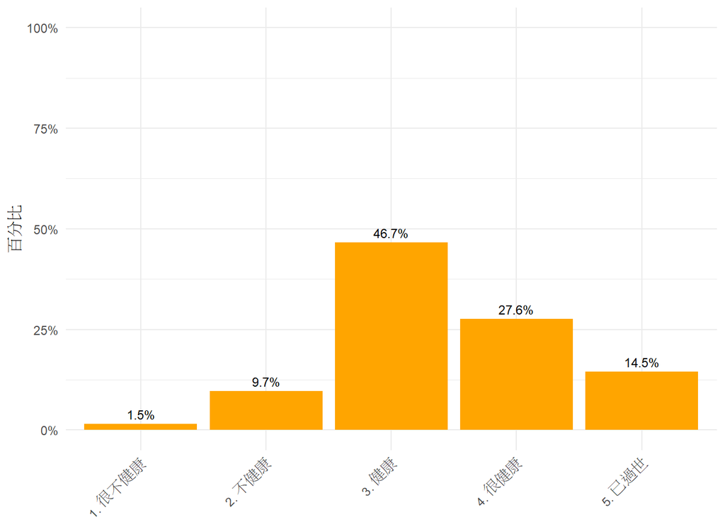

### 上一代_自己母親婚姻狀況 (樣本數=4224)

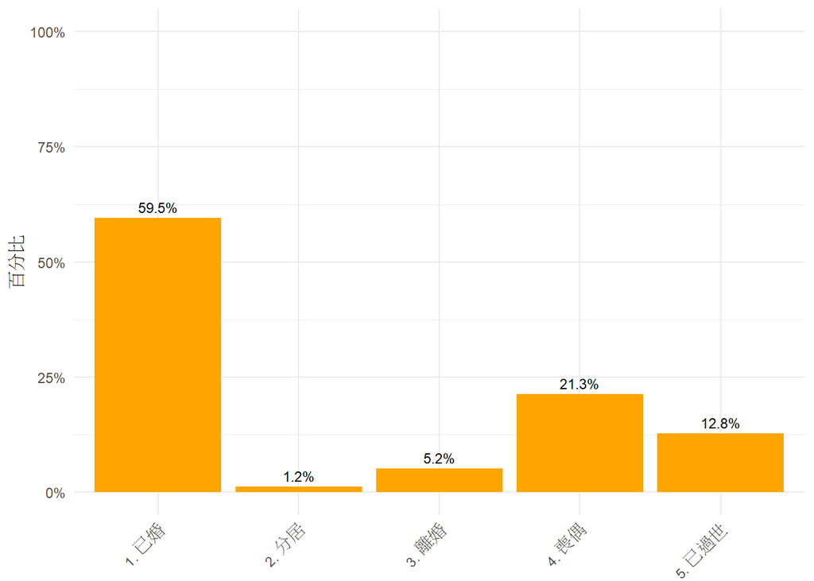

### 上一代_自己母親工作狀況 (樣本數=4195)

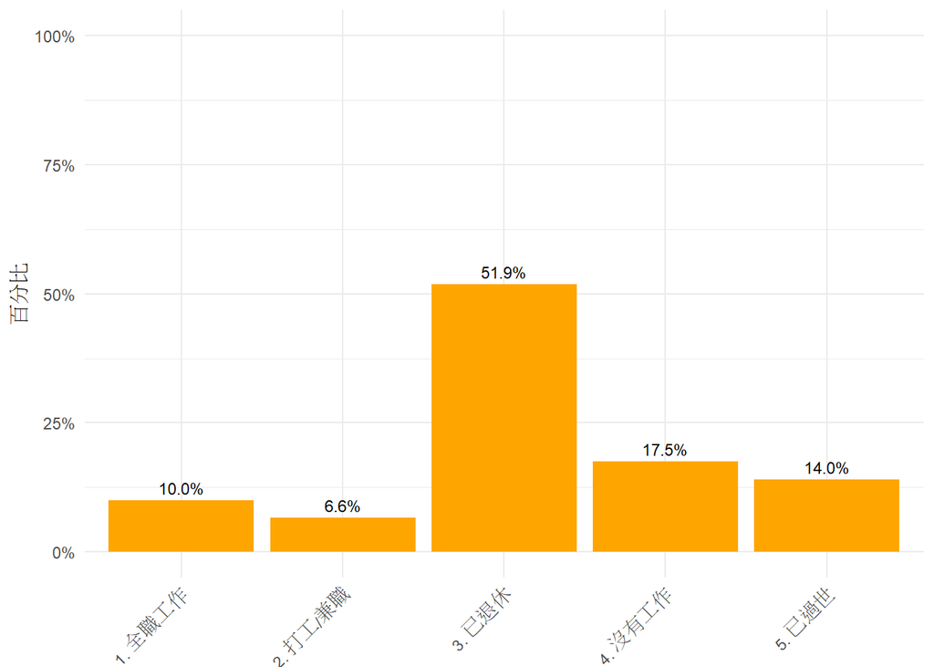

### 上一代_自己母親和照顧者感情好不好 (樣本數=4257)

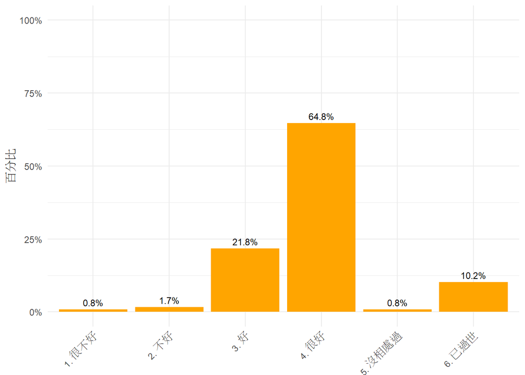

### 上一代_配偶父親年齡 (樣本數=3600)

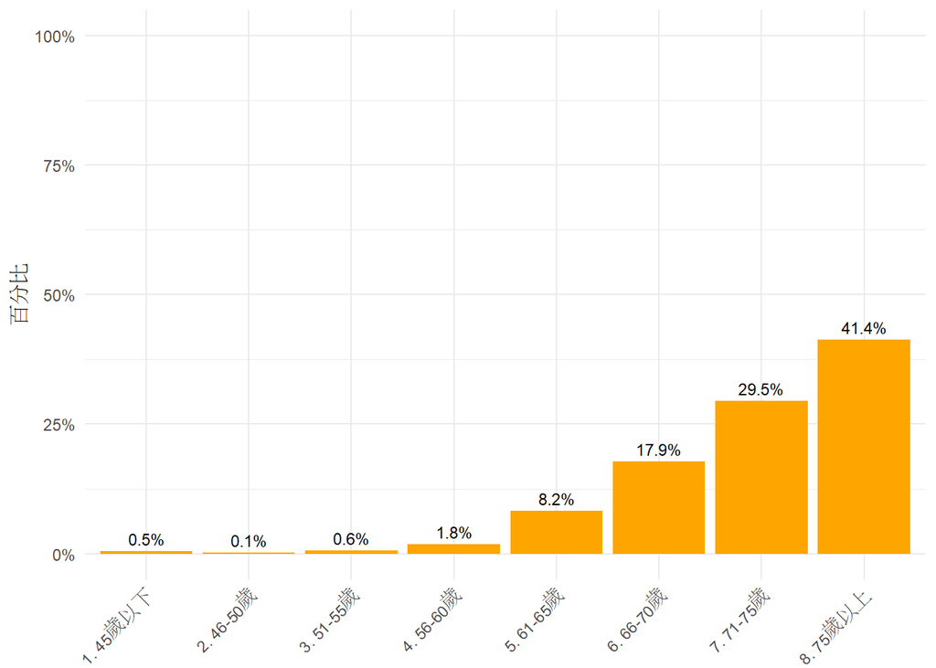

### 上一代_配偶父親教育程度 (樣本數=3143)

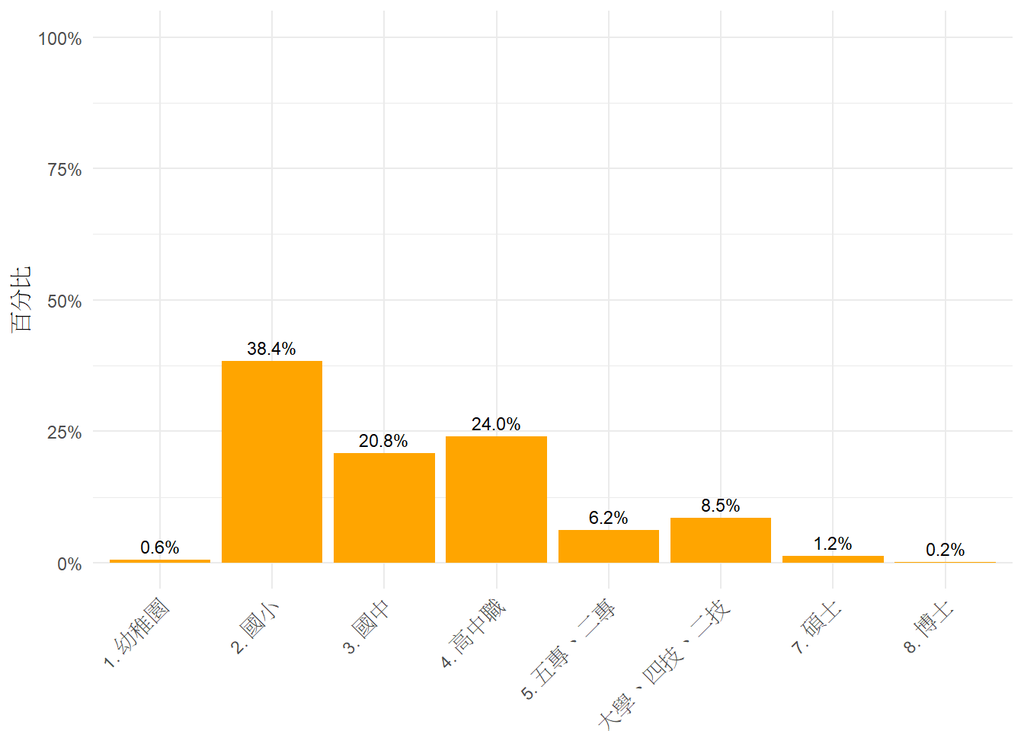

### 上一代_配偶父親健康狀況 (樣本數=4021)

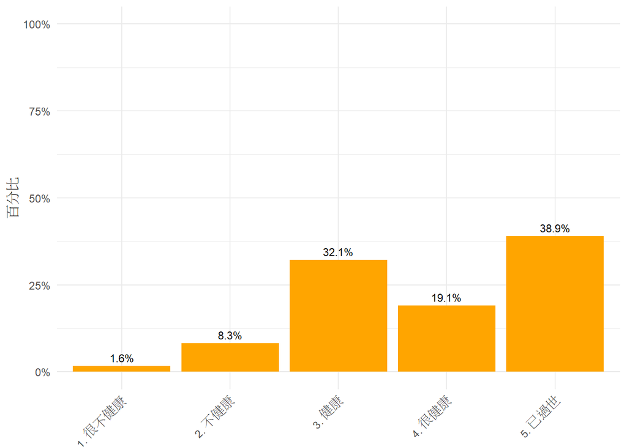

### 上一代_配偶父親婚姻狀況 (樣本數=4078)

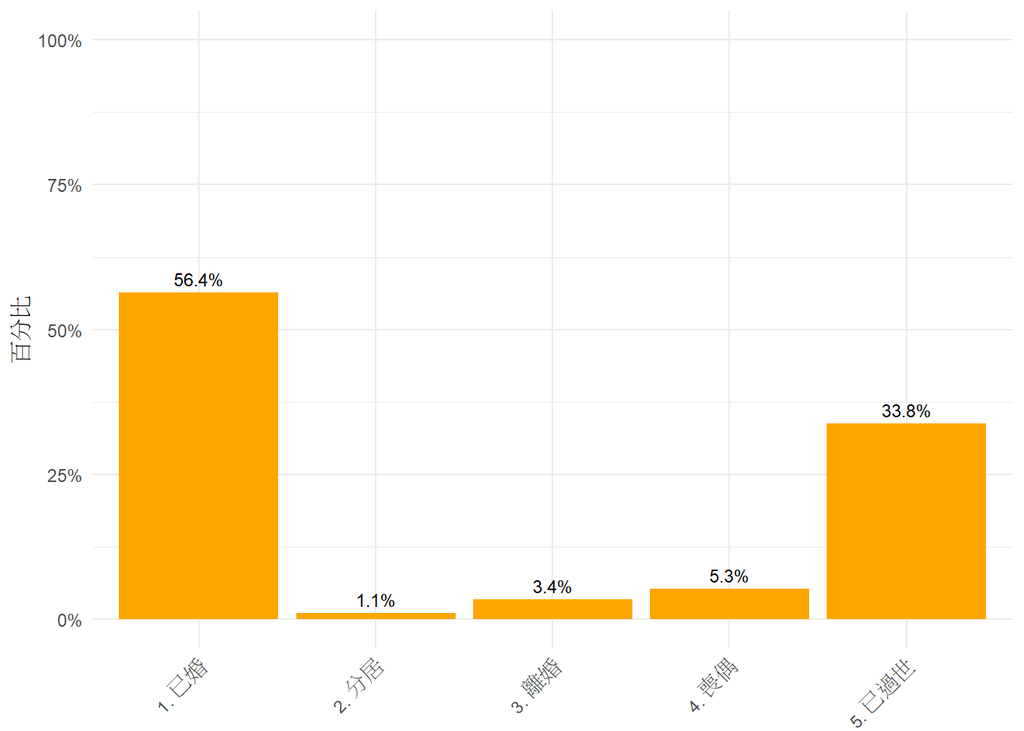

### 上一代_配偶父親工作狀況 (樣本數=4018)

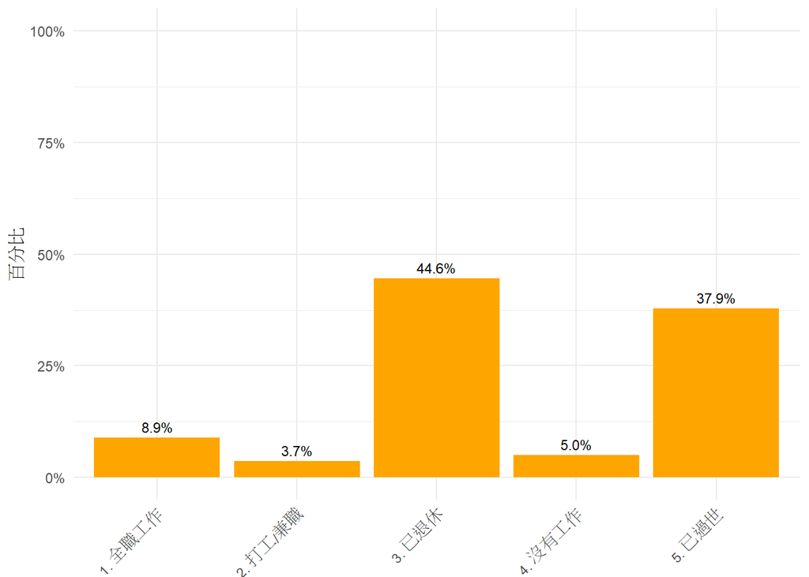

### 上一代_配偶父親和照顧者感情好不好 (樣本數=3048)

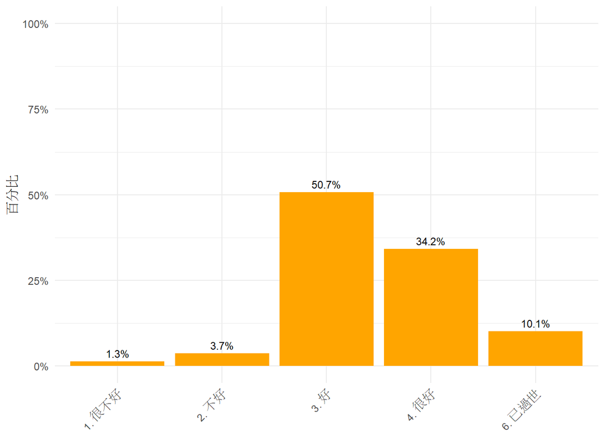

### 上一代_配偶母親年齡 (樣本數=2817)

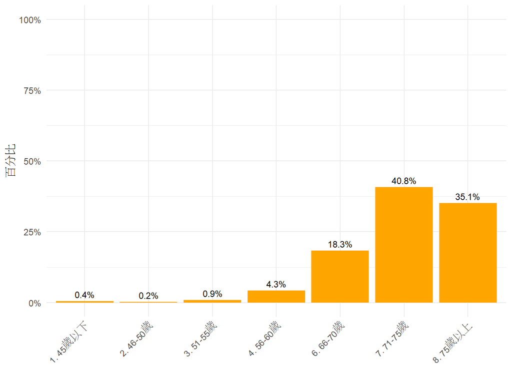

### 上一代_配偶母親教育程度 (樣本數=3007)

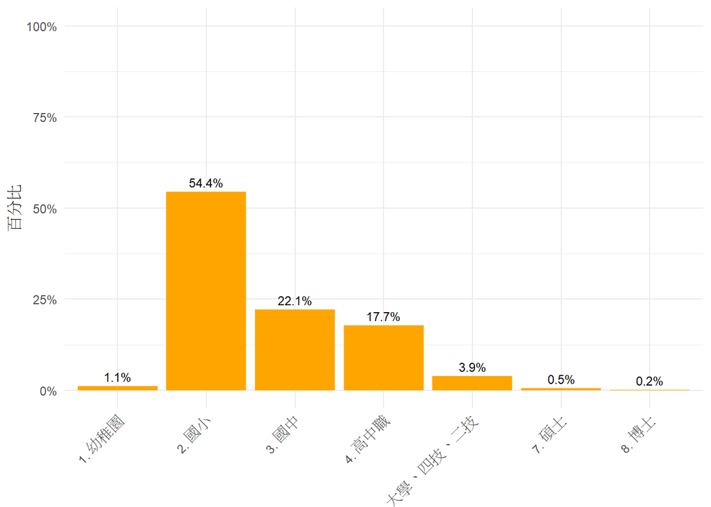

### 上一代_配偶母親健康狀況 (樣本數=4014)

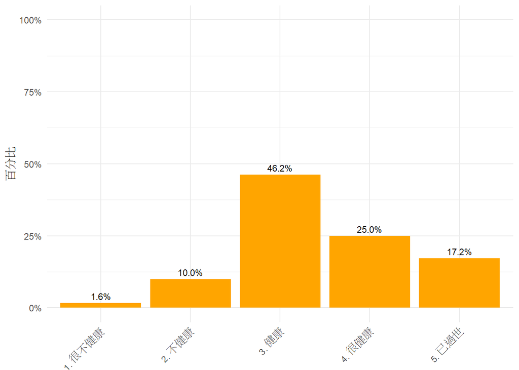

### 上一代_配偶母親婚姻狀況 (樣本數=4082)

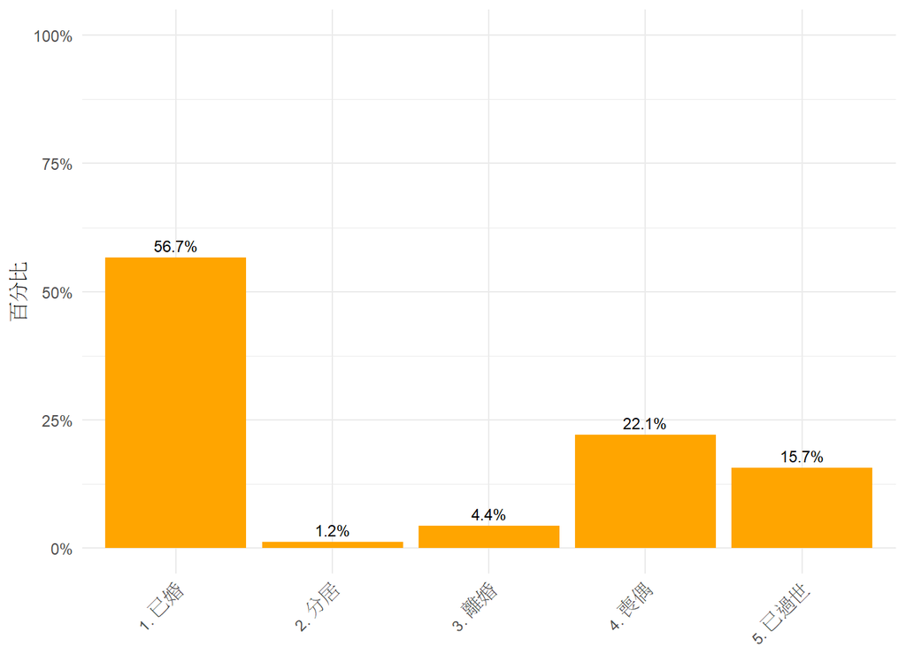

### 上一代_配偶母親工作狀況 (樣本數=4006)

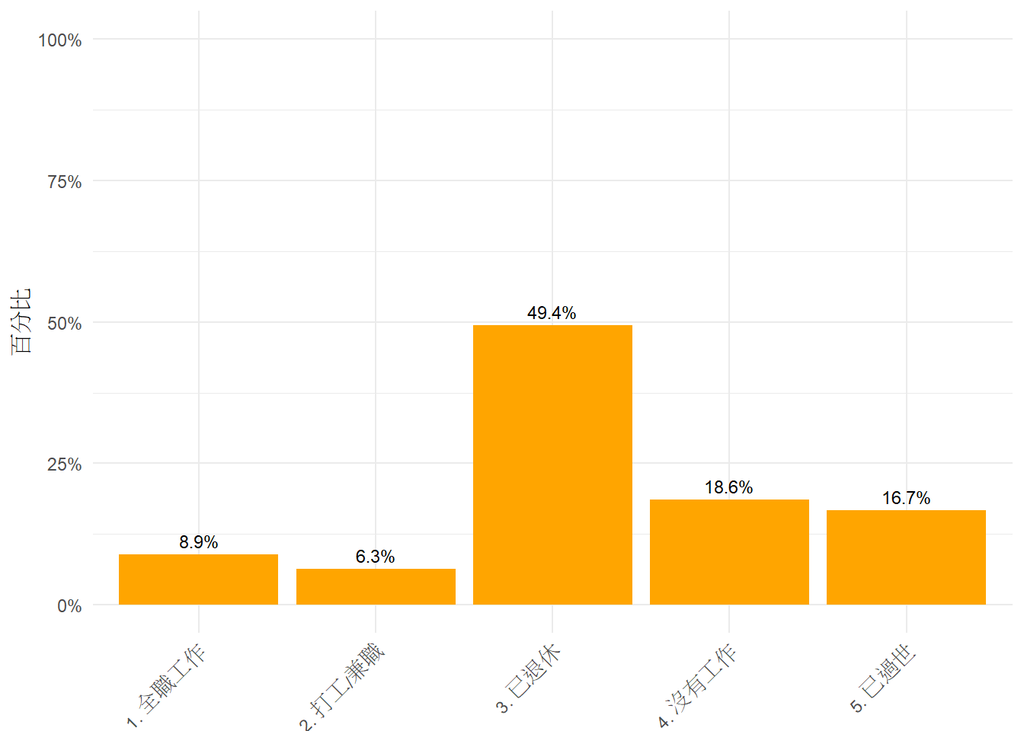

### 上一代_配偶母親和照顧者感情好不好 (樣本數=4254)

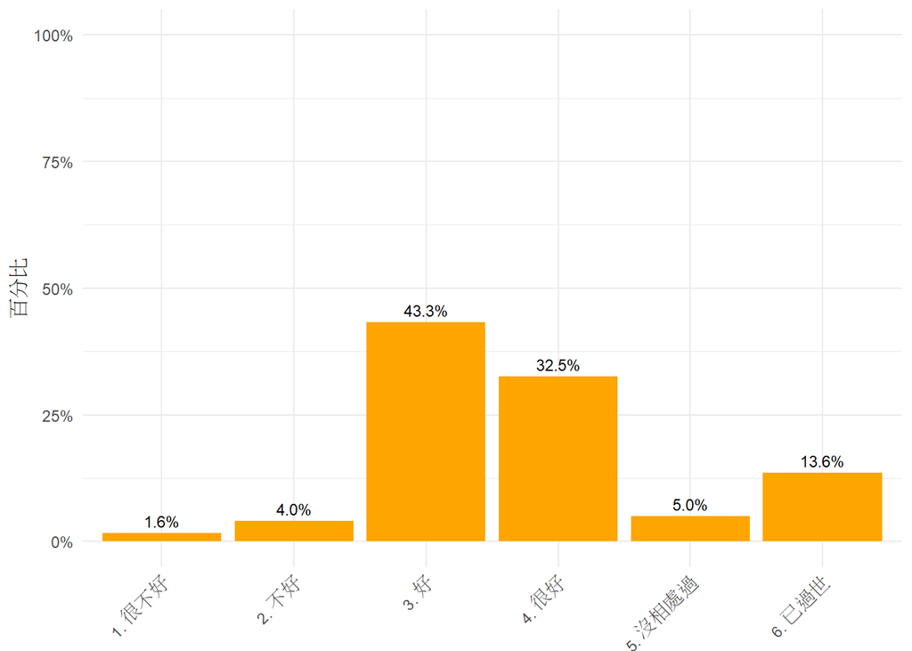

### 上一代_父母感情 (樣本數=4154)

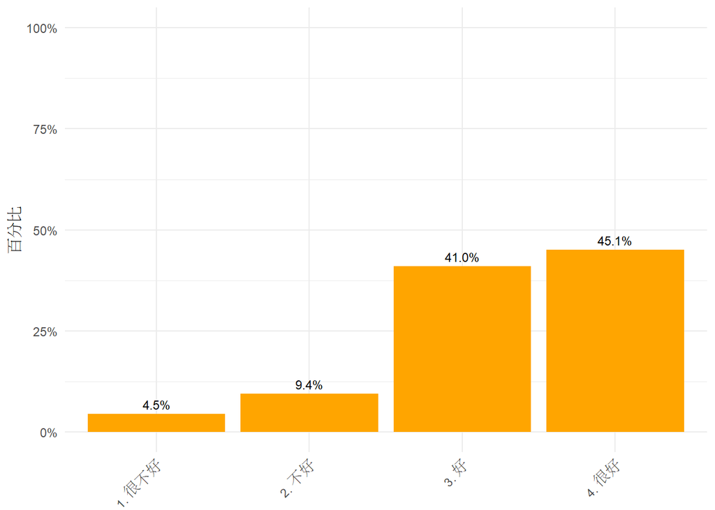

### 上一代_配偶父母感情 (樣本數=3706)

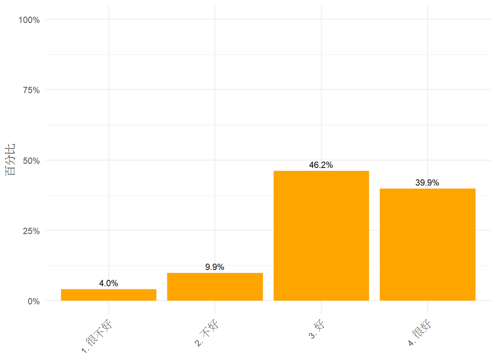

### 上一代_與父母相處壓力 (樣本數=4274)

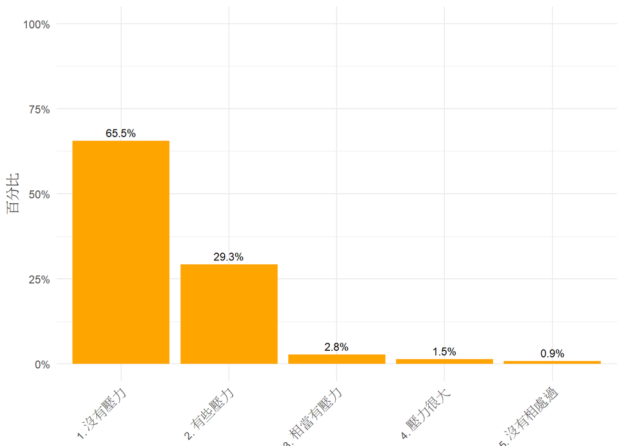

### 上一代_與配偶父母相處壓力 (樣本數=4272)

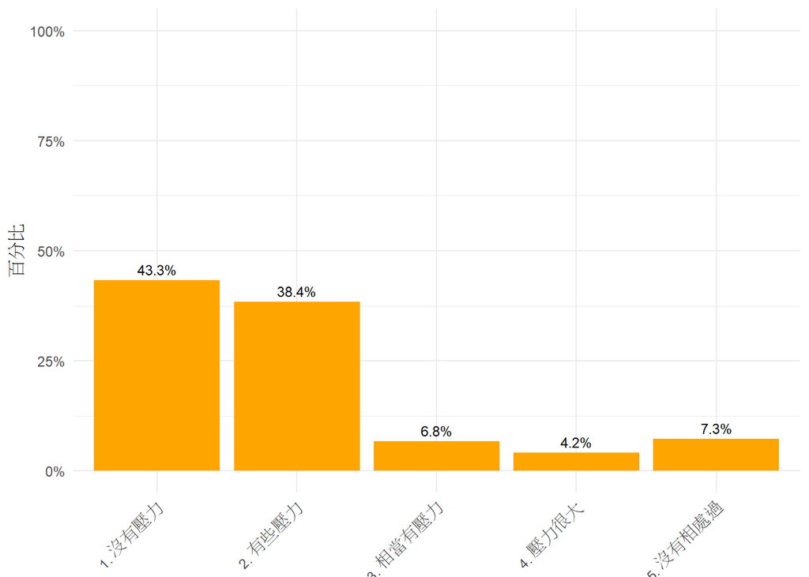

### 家庭凝聚力_作決定時，家人會彼此商量 (樣本數=4267)

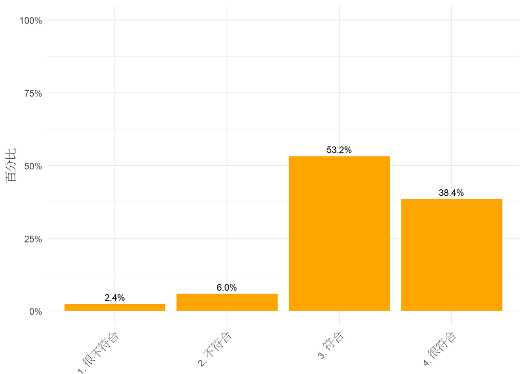

### 家庭凝聚力_家人喜歡共度休閒時光 (樣本數=4266)

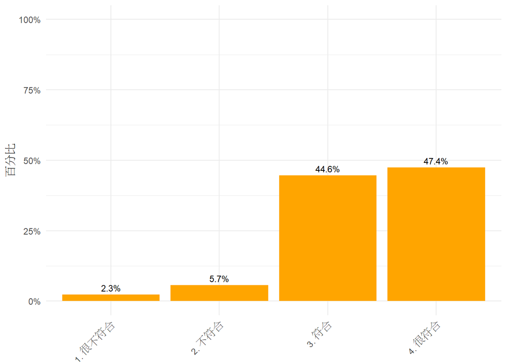

### 家庭凝聚力_當有家庭活動時，我們家每個人都會參加 (樣本數=4267)

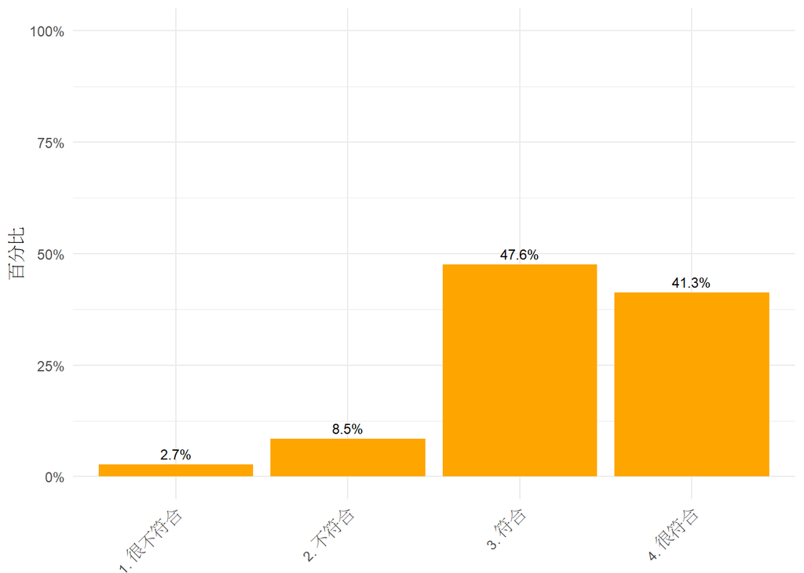

### 家庭凝聚力_家人會接納彼此的朋友 (樣本數=4267)

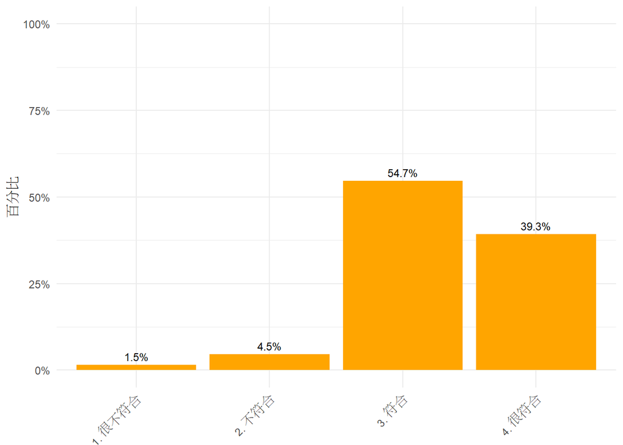

### 家庭凝聚力_我受到挫折時，總可以從我的家人那裡得到安慰 (樣本數=4266)

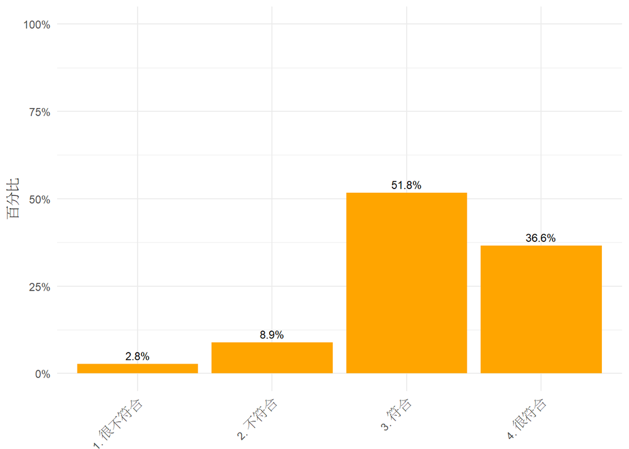

### 家庭凝聚力_當我需要幫忙或忠告時，我可以依賴我的家人 (樣本數=4267)

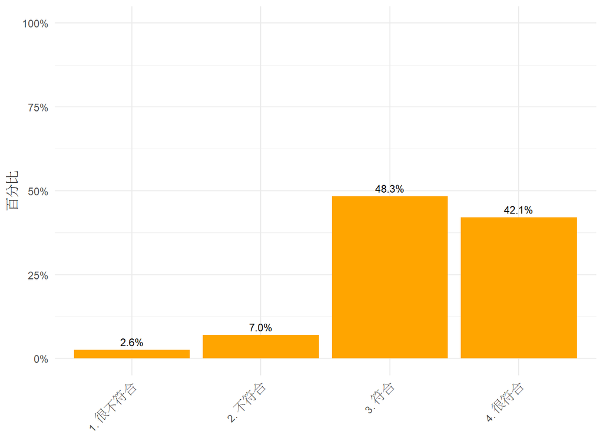

### 生活滿意度 (樣本數=4263)

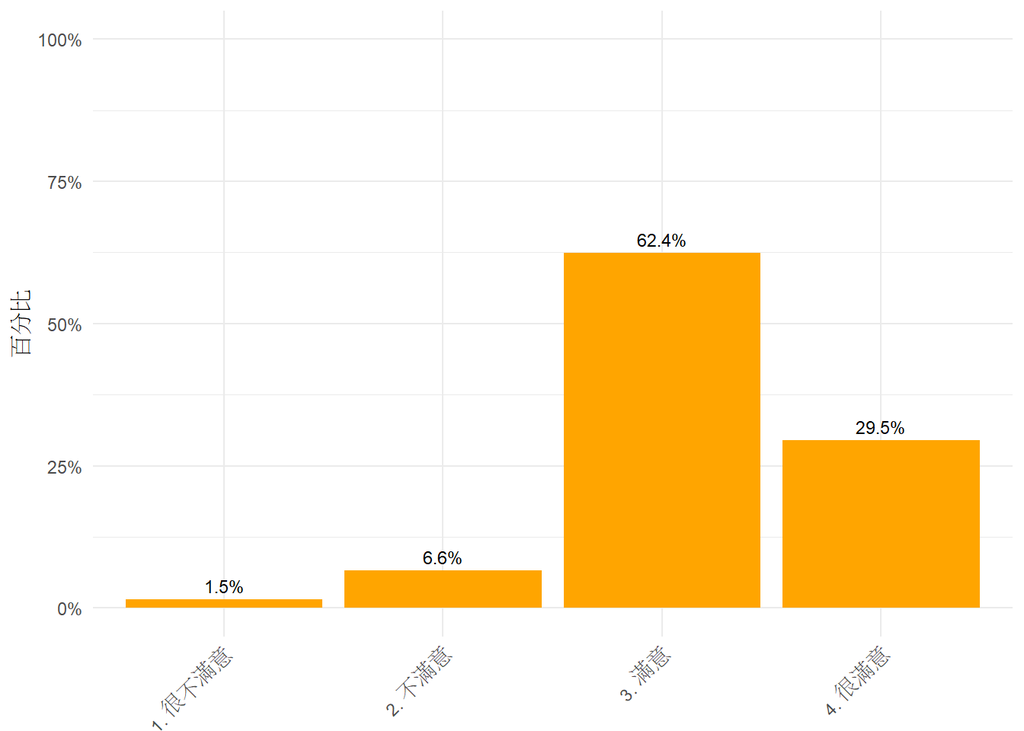

### 幸福感(快樂) (樣本數=4256)

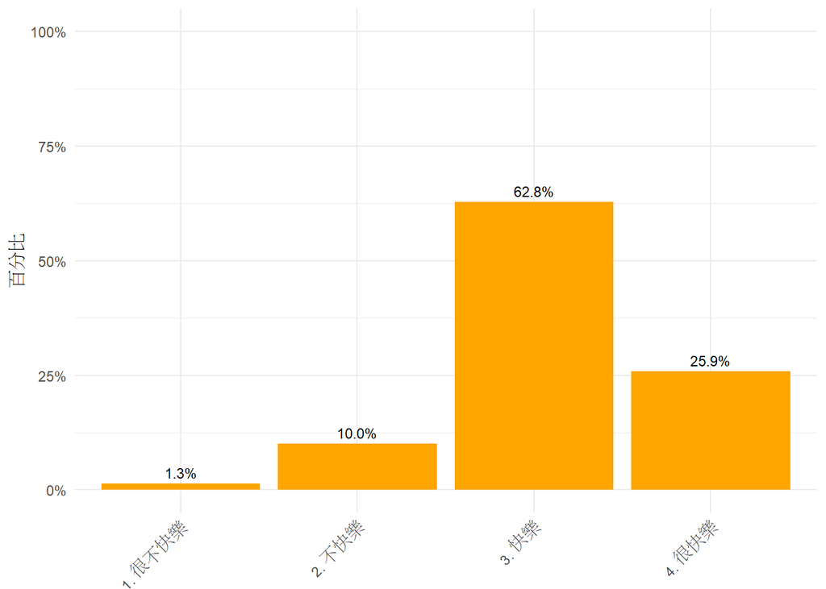

### 自覺健康 (樣本數=4263)

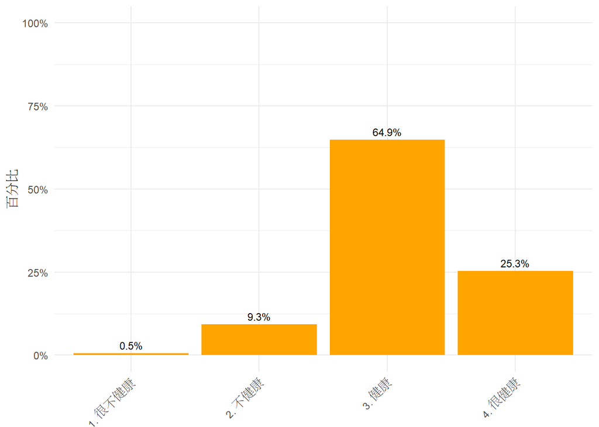

### 家庭經濟 (樣本數=4262)

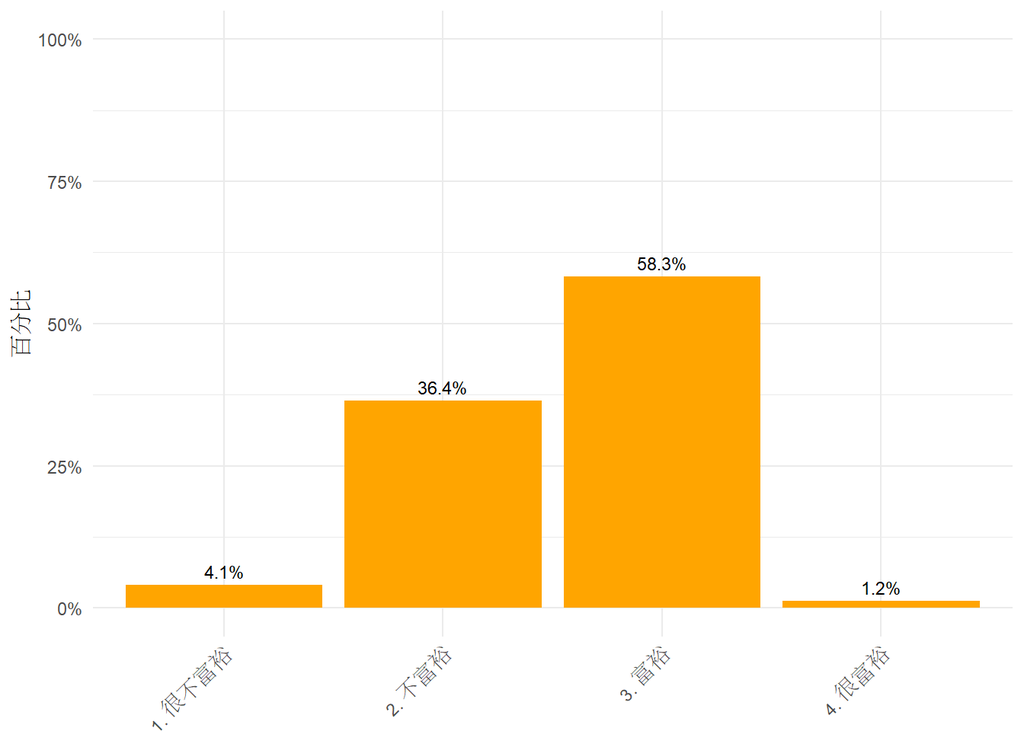

### 教養孩子做人處事原則_孝順父母 (樣本數=4250)

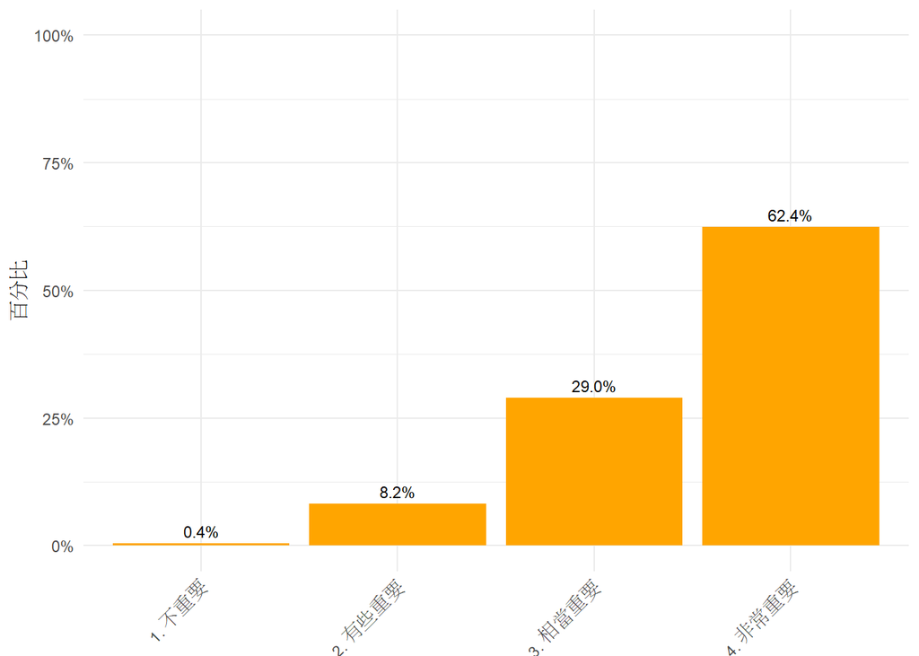

### 教養孩子做人處事原則_對大人有禮貌 (樣本數=4250)

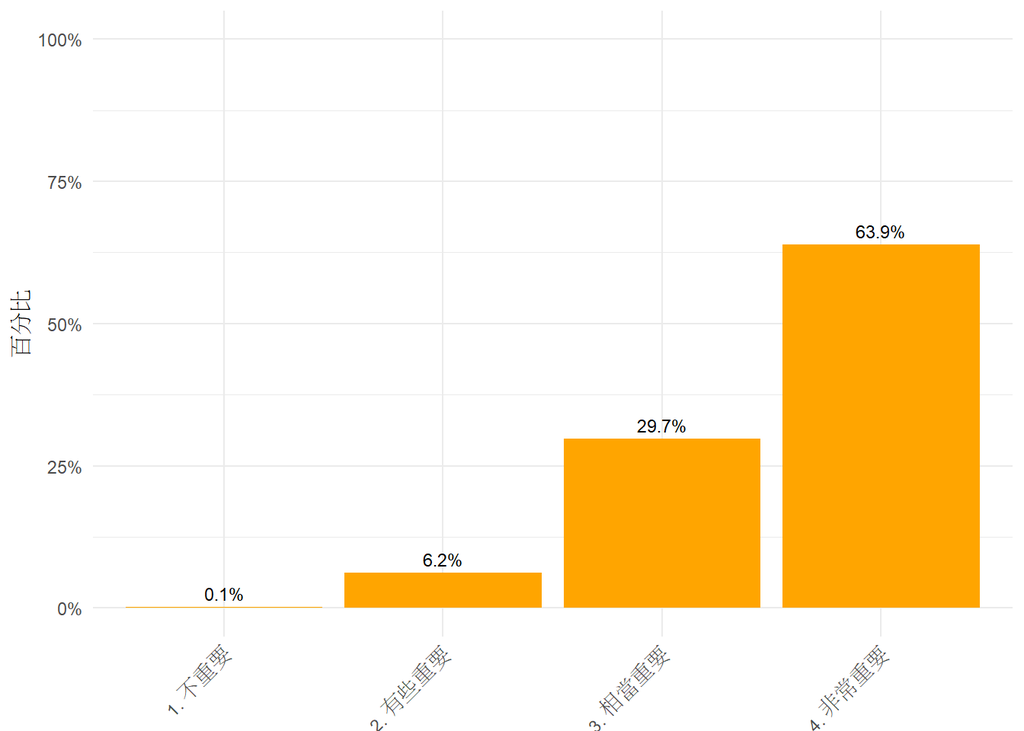

### 教養孩子做人處事原則_服從父母和老師 (樣本數=4250)

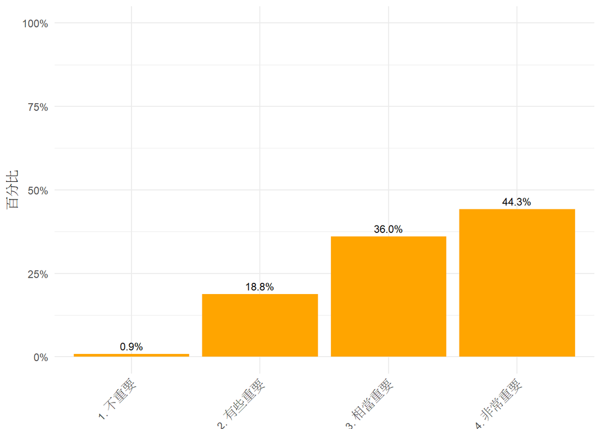

### 教養孩子做人處事原則_不要出風頭 (樣本數=4250)

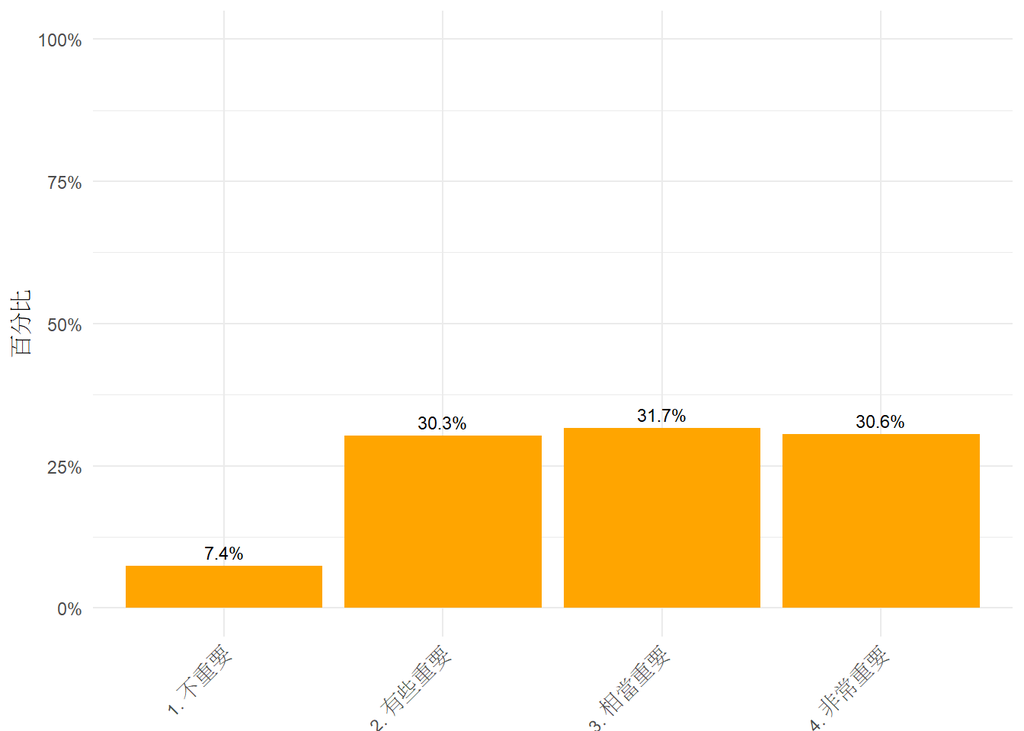

### 教養孩子做人處事原則_生活節儉 (樣本數=4250)

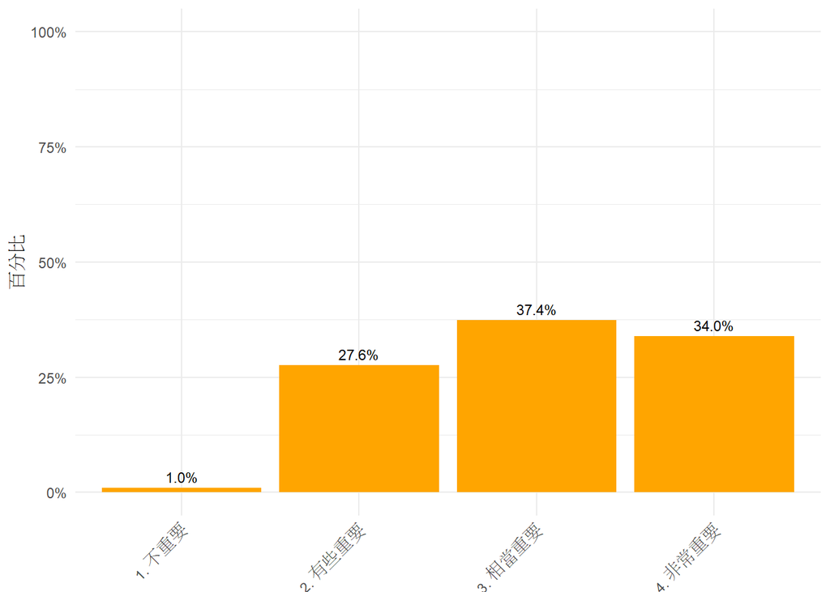

### 教養孩子做人處事原則_要能忍耐 (樣本數=4250)

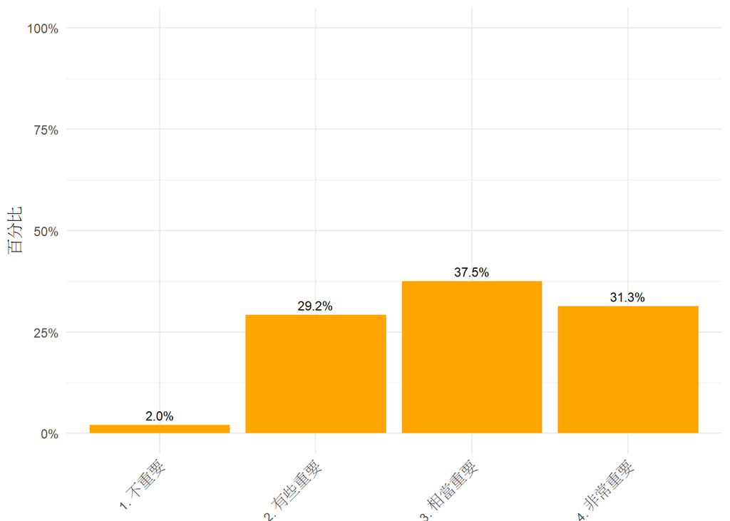

### 教養孩子做人處事原則_對許多事情有好奇心 (樣本數=4250)

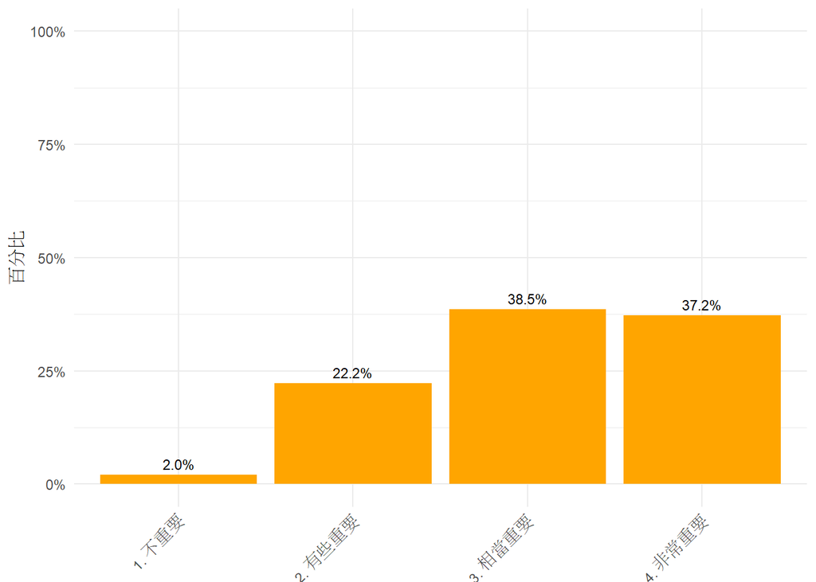

### 教養孩子做人處事原則_有想像力 (樣本數=4250)

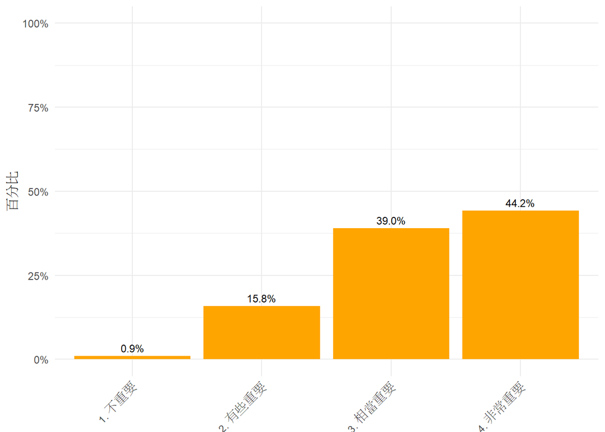

### 教養孩子做人處事原則_喜歡探索事情發生的原因 (樣本數=4250)

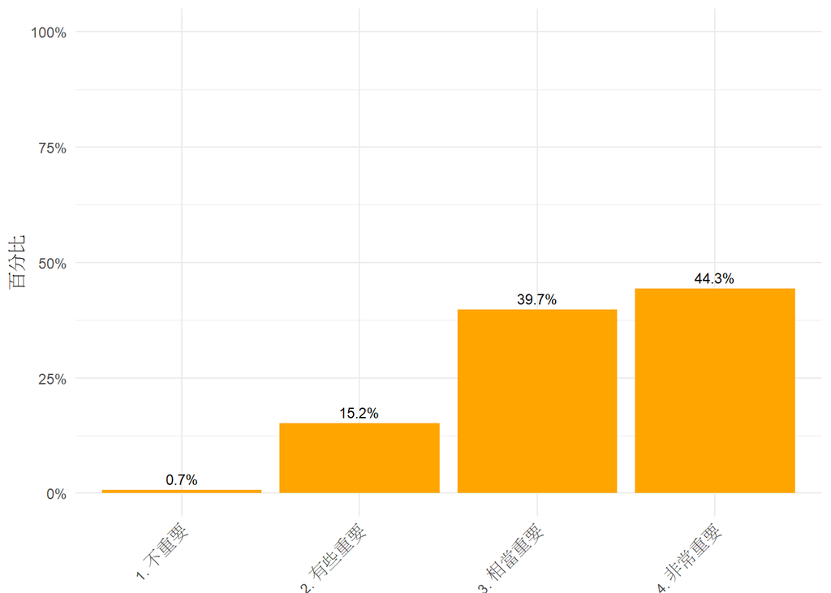

### 教養孩子做人處事原則_對自己份內的工作負責 (樣本數=4250)

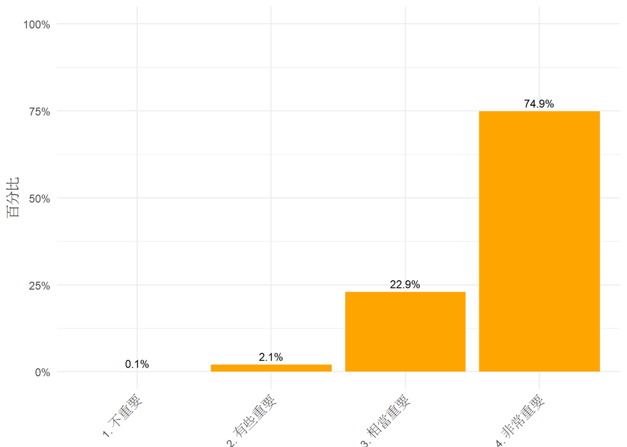

### 教養孩子做人處事原則_有能力照顧自己 (樣本數=4250)

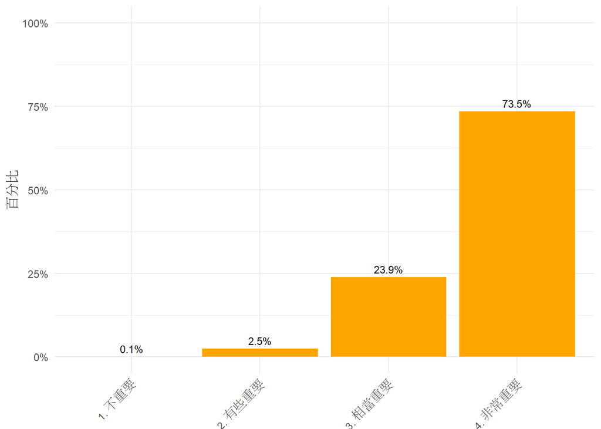

### 教養孩子做人處事原則_做人守信用 (樣本數=4250)

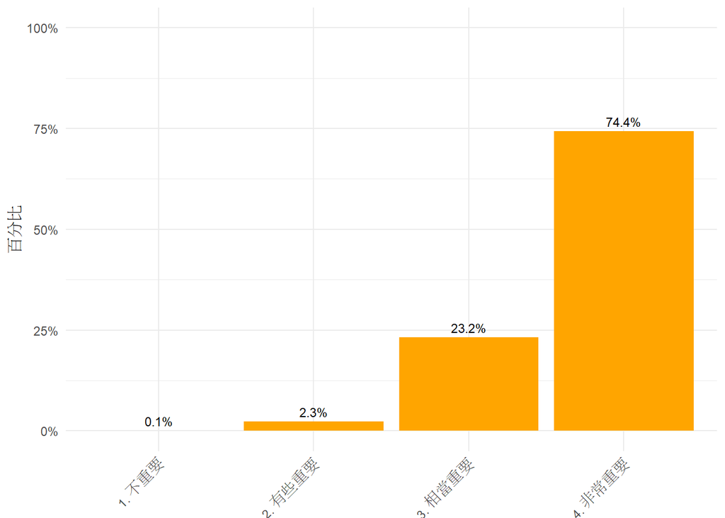

### 教養孩子做人處事原則_為別人著想 (樣本數=4250)

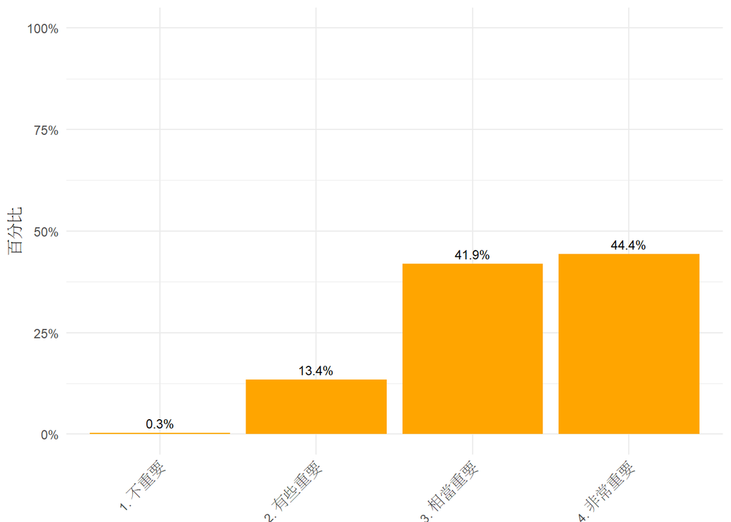

### 教養孩子做人處事原則_與別人和睦相處 (樣本數=4249)

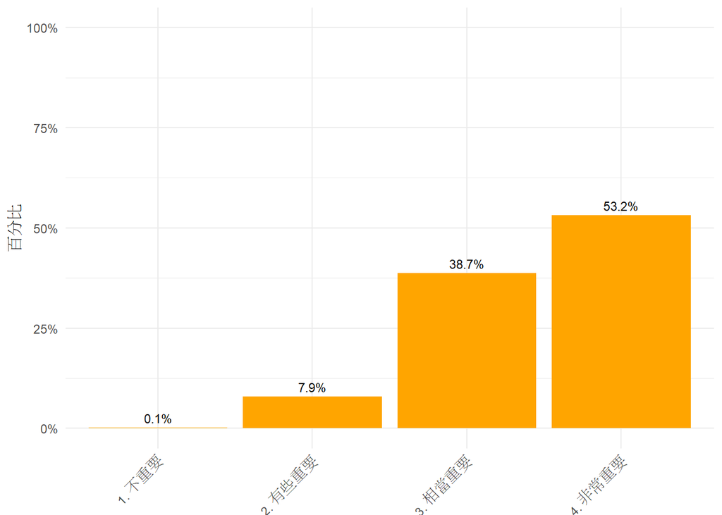

### 教養孩子做人處事原則_待人謙虛 (樣本數=4250)

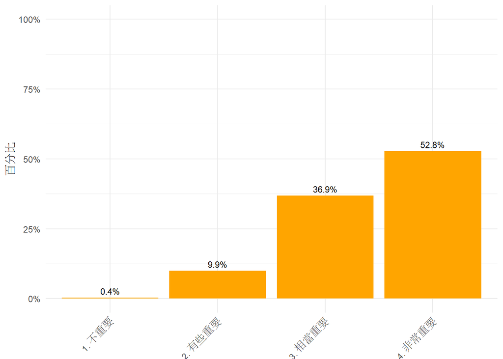

### 晚餐共餐_在家吃 (樣本數=4256)

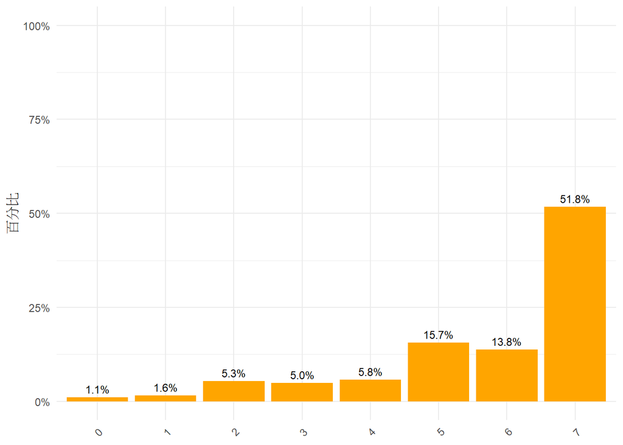

### 晚餐共餐_國七小孩共餐 (樣本數=4248)

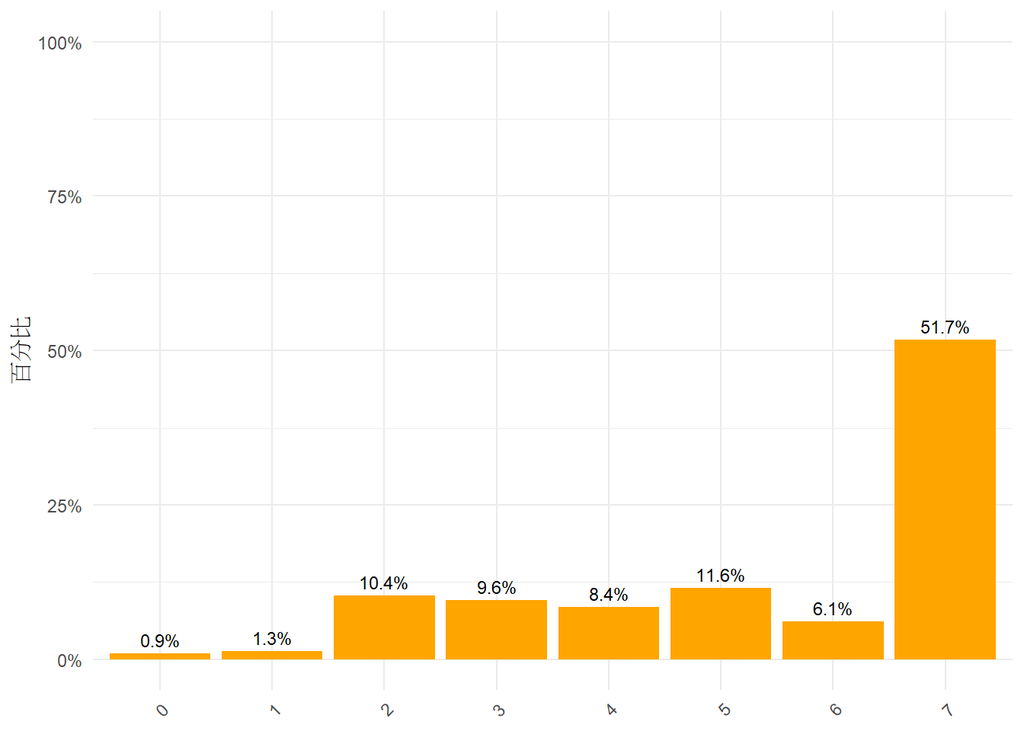

### 子女表現_不想上學而賴床、裝病 (樣本數=4232)

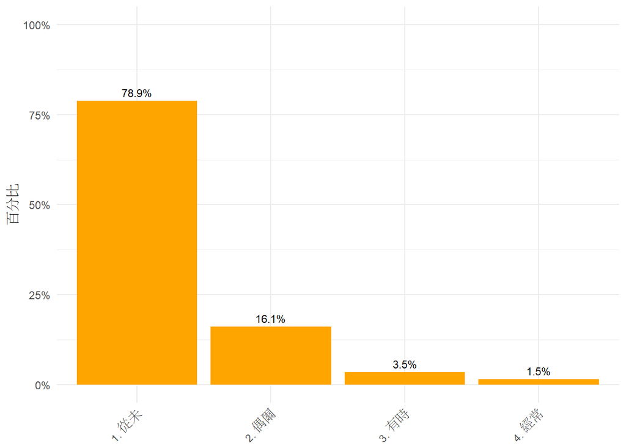

### 子女表現_蹺課、逃學、故意不去上學或在學校裡惹麻煩 (樣本數=4241)

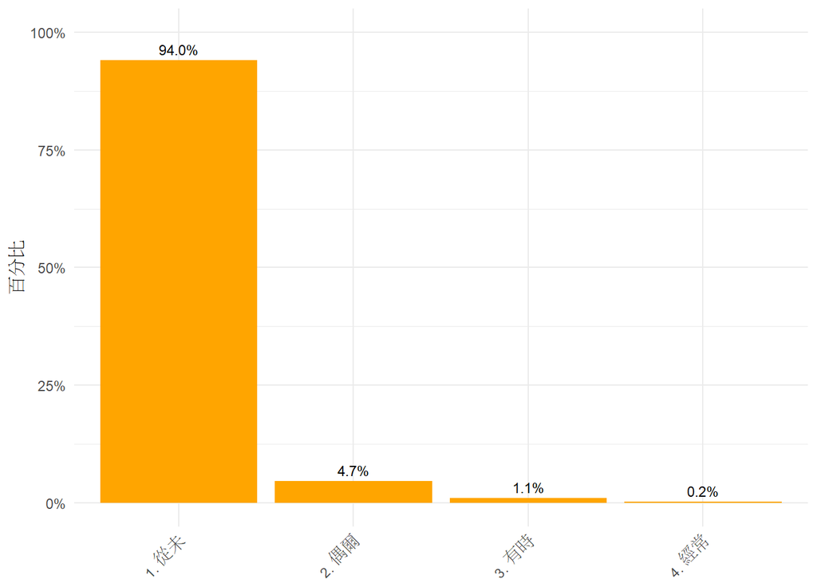

### 子女表現_在校成績表現 (樣本數=4252)

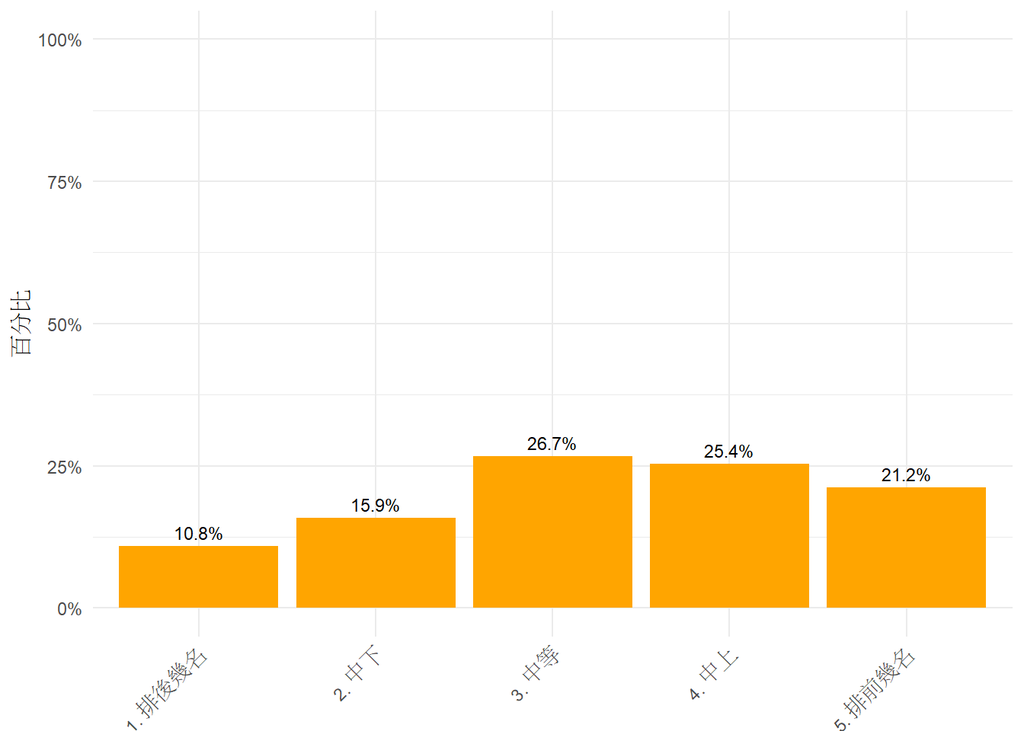

### 子女表現_成績滿意 (樣本數=4257)

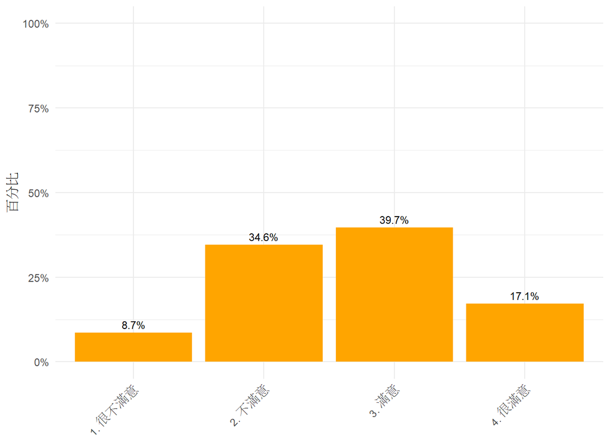

### 親子互動與教養實施_孩子批評您或指責您 (樣本數=4243)

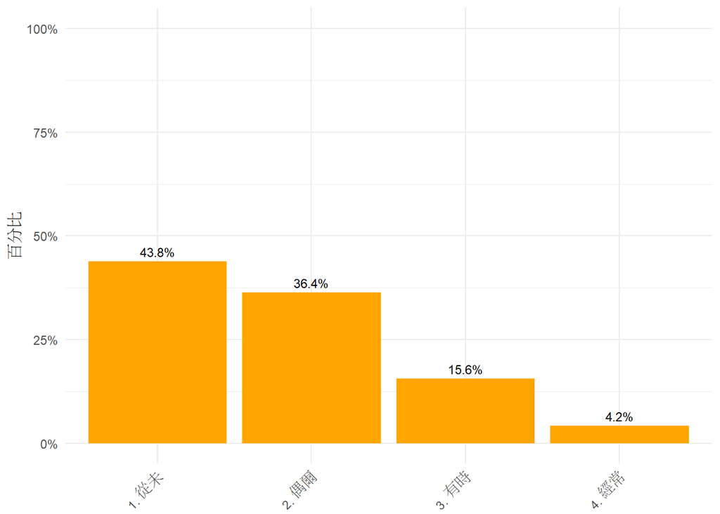

### 親子互動與教養實施_孩子理解您、肯定您的想法 (樣本數=4246)

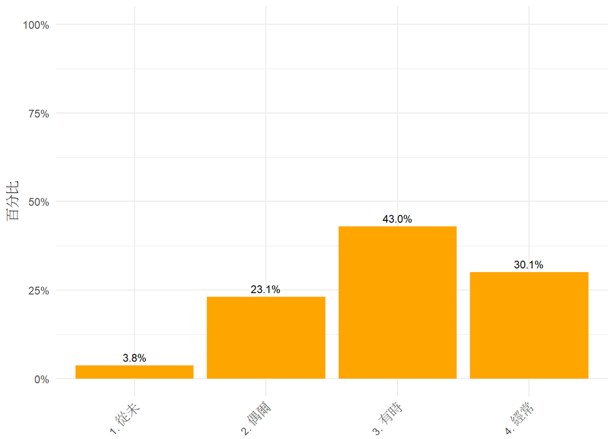

### 親子互動與教養實施_孩子關心您 (樣本數=4246)

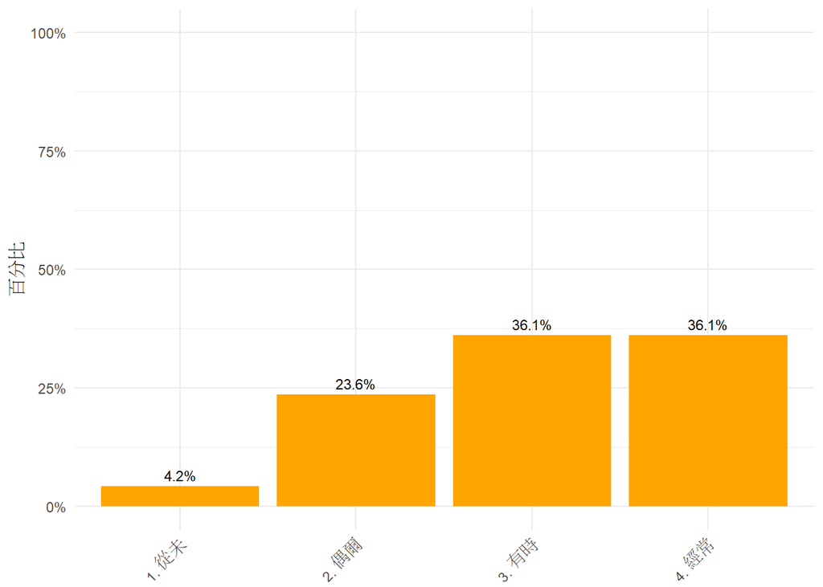

### 親子互動與教養實施_孩子提供解決問題的經驗，給您參考 (樣本數=4246)

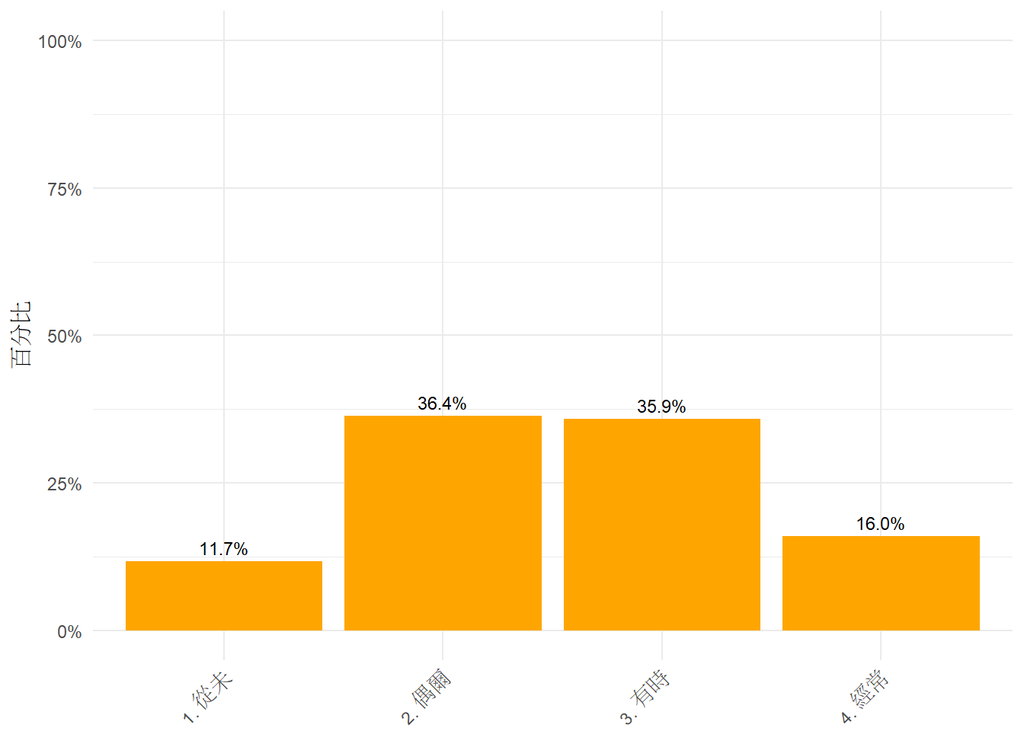

### 親子互動與教養實施_孩子對您不聞不問 (樣本數=4246)

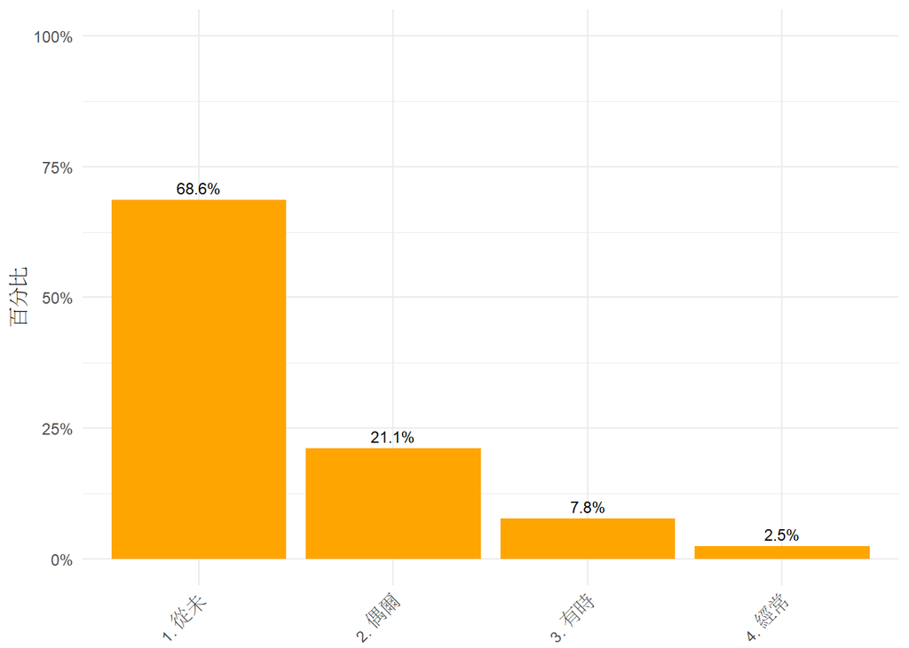

### 親子互動與教養實施_孩子跟您常有衝突，彼此關係緊張 (樣本數=4246)

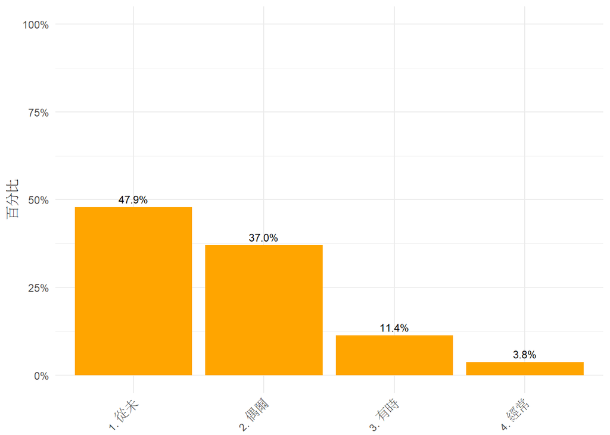

### 親子互動與教養實施_您知道孩子每天的行蹤 (樣本數=4246)

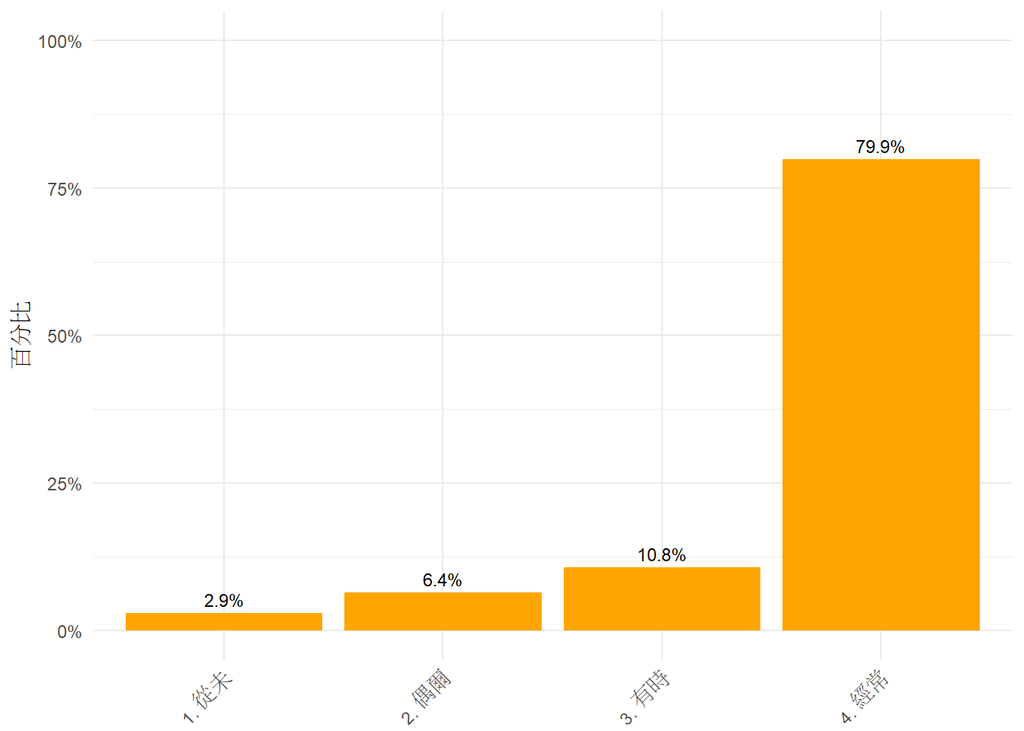

### 親子互動與教養實施_同樣一件事，您有時處罰小孩，有時不處罰 (樣本數=4246)

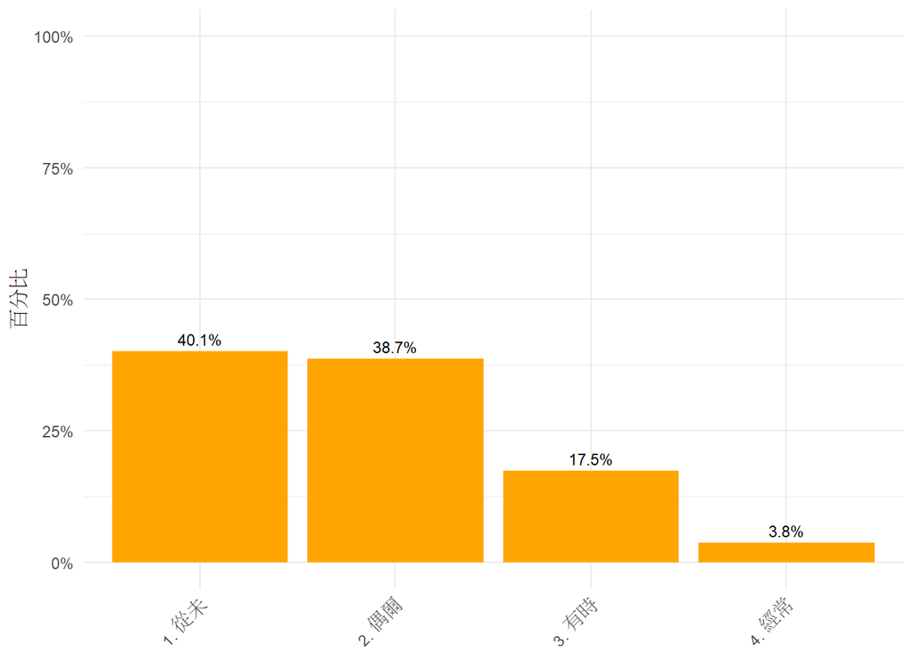

### 親子互動與教養實施_處罰孩子時，您會打他 (樣本數=4246)

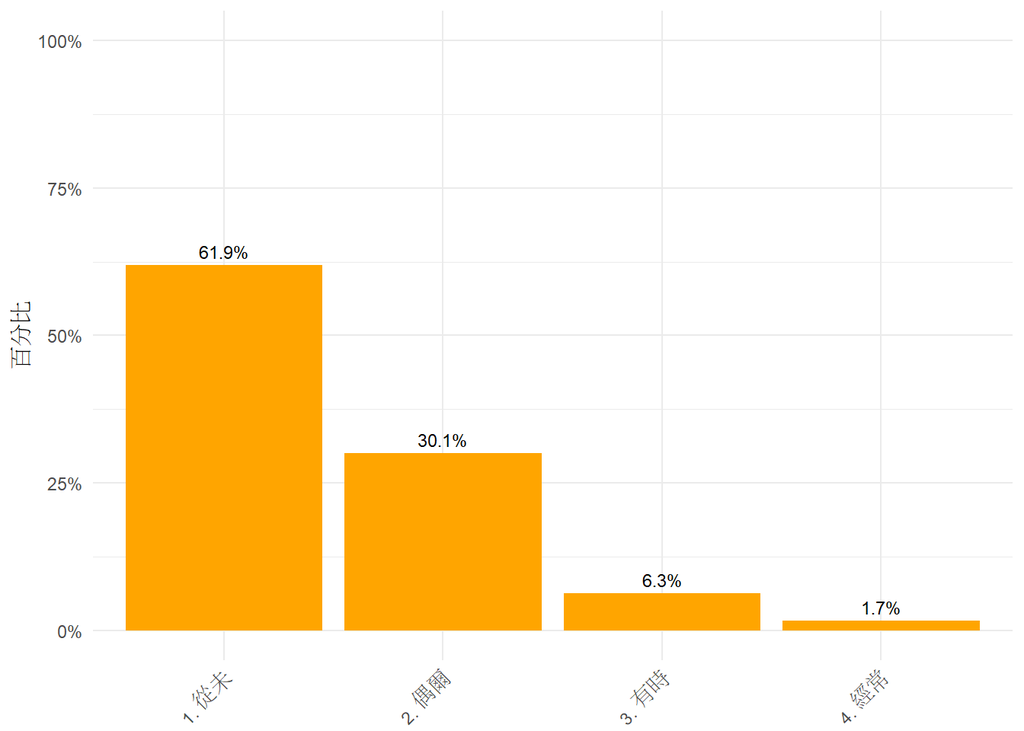

### 親子互動與教養實施_有關孩子的事，您會告訴他您的想法 (樣本數=4246)

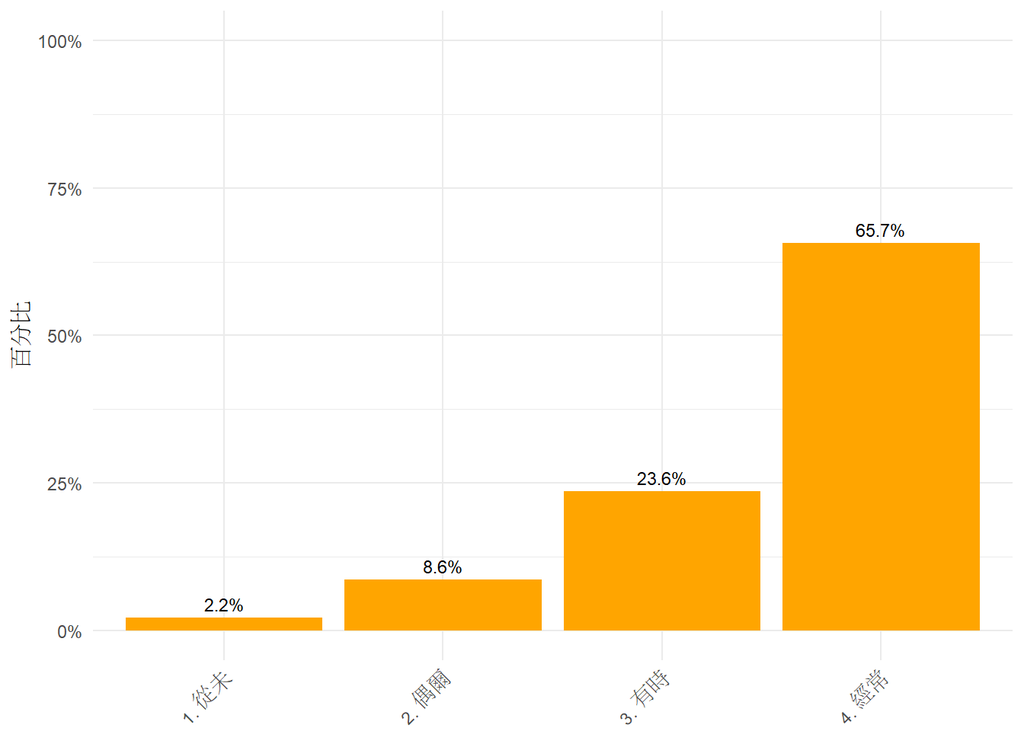